# Projekt

Zbadajmy teraz zależność między tymi zmiennymi. Użyjemy metody powszechnie stosowanej już w tej pracy tzn. ekstrację trendu.

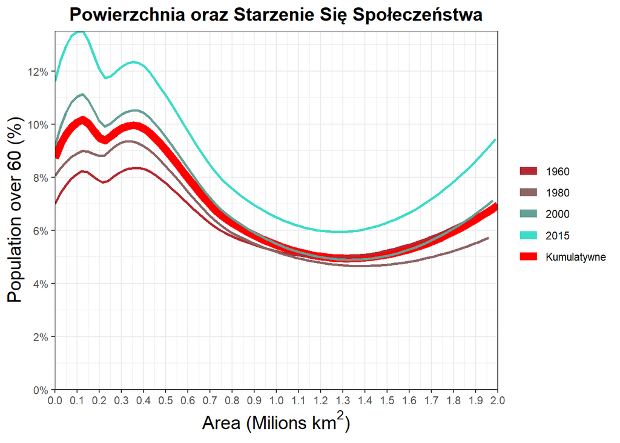

```r
ggplot() +
  geom_smooth(aes(Area, Population_over_60 / 100,
                  color = 'Kumulatywne'),
              data %>%
                filter(Area <= 2), se = F,
              method = 'loess', formula = y ~ x, linewidth = 3) +
  geom_smooth(aes(Area, Population_over_60 / 100,
                  color = '1960'), data_1960 %>%
                filter(Area <= 2), se = F,
              method = 'loess', formula = y ~ x) +
  geom_smooth(aes(Area, Population_over_60 / 100,
                  color = '1980'), data_1980 %>%
                filter(Area <= 2), se = F,
              method = 'loess', formula = y ~ x) +
  geom_smooth(aes(Area, Population_over_60 / 100,
                  color = '2000'), data_2000 %>%
                filter(Area <= 2), se = F,
              method = 'loess', formula = y ~ x) +
  geom_smooth(aes(Area, Population_over_60 / 100,
                  color = '2015'), data_2015 %>%
                filter(Area <= 2), se = F,
              method = 'loess', formula = y ~ x) +
  ggtitle('Powierzchnia oraz Starzenie Się Społeczeństwa') +
  labs(x = TeX('Area (Milions $km^2$)'),
       y = 'Population over 60 (%)', parse = T,
       color = NULL) +
  expand_limits(x = 0, y = 0) +
  scale_x_continuous(expand = c(0, NA),breaks = seq(0, 2, 0.1)) +
  scale_y_continuous(expand = c(0, NA), breaks = seq(0, 1, 0.02),
                     labels = scales::percent) +
  theme_bw() +
  theme(plot.title = element_text(size = 15, face = 'bold', hjust = 0.5),
        axis.title.x = element_text(size = 15),
        axis.title.y = element_text(size = 15)) +
  scale_color_manual(values = colors)
```

Widzimy tutaj ciekawą zależność, która nie jest do końca jednoznaczna. Kraje o niskiej powierzchni są generalnie społeczeństwami starami, jednak trend nie jest jednoznacznie malejący, gdyż kraje o bardzo wysokiej powierzchni są generalnie  
bardziej rozwinięte niż te o umiarkowanie dużej powierzchni.

## Podsumowanie

Zależność jaką otrzymaliśmy jest praktycznie odwrotna do spodziewanej. Generalnie najbardziej “stare” kraje mają dosyć niską powierzchnią. Po głębszym przemyśleniu może to mieć sens, gdyż w tym przedziale znajduje się większość krajów europejskich. Analizę krajów o bardzo wysokiej powierzchnii pomijamy w tej pracy.

# Zakończenie

Udało nam się zbadać wiele zależności między różnymi cechami społeczeństw. Nie wszystkie wyniki jakie otrzymaliśmy były takie jakich się spodziewaliśmy, jednak udało się nam potwierdzić dużą część naszych hipotez.

Mam nadzieję, że praca ta zaciekawiła oraz zinspirowała czytelnika do dalszego poszukiwania informacji o zależnościach pomiędzy różnymi cechami społeczeństw oraz krajów.